# Analysis

viernes 29 julio 2022 10:17:55

# 1 Objective

Exploratory underlying dimensions (EFA)

# 2 Libraries

```r
# if (!require("pacman")) install.packages("pacman") # instalar pacman
pacman::p_load(dplyr,       # Manipulacion de datos
               sjmisc,      # descriptivos y frecuencias
               sjPlot,      # tablas, plots y descriptivos
               responsePatterns, # detect careless resp.
               corrplot,     # plot correlacion
               psych, # EFA
               EFAutilities, #EFA
               lavaan  # CFA
               )
```

# 3 Pilot study

## 3.1 Data

```r
load(file = "01-input/data/proc/data_cohes_pilot.Rdata" )
names(data_cohes_pilot)
```

```
##  [1] "pid"      "pcohes01" "pcohes02" "pcohes03" "pcohes04" "pcohes05"
##  [7] "pcohes06" "pcohes07" "pcohes08" "pcohes09" "pcohes10" "careless"
```

```r
# stargazer(as.data.frame(data_cohes), type="text")
```

## 3.2 Bivariate

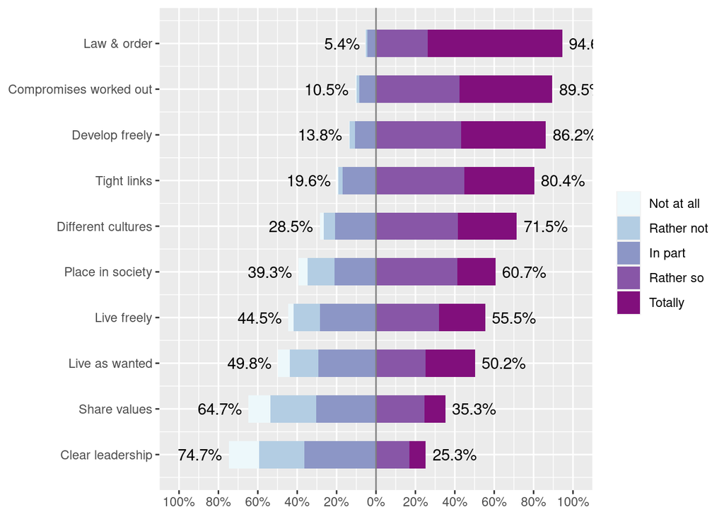

```r
data_cohes_pilot %>% select(pcohes05,pcohes07,pcohes02, pcohes09, pcohes04,pcohes01,pcohes10,pcohes06,pcohes03,pcohes08) %>% plot_likert(.,
  values = "sum.outside",
  show.prc.sign = TRUE,
  reverse.scale = TRUE,
  expand.grid = T,
  catcount = 5,
  show.n = FALSE,
  geom.colors = "BuPu")
```

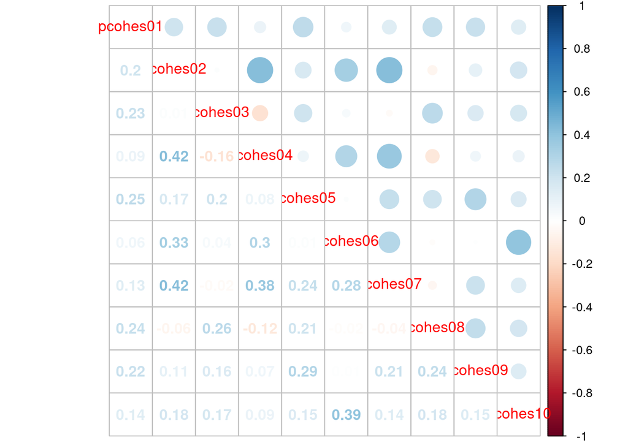

```r
M_pilot <- cor(na.omit(data_cohes_pilot %>% select(pcohes01:pcohes10)))

corrplot.mixed(M_pilot)
```

## 3.3 Factor analysis

### 3.3.1 Estimate with fa (psych library)

```r
data_cohes_efa <- data_cohes_pilot %>% select(pcohes01:pcohes10)

M1_pilot <- fa (data_cohes_efa, nfactors=3, rotate="oblimin", fm="ml")
M1_pilot
```

```
## Factor Analysis using method =  ml
## Call: fa(r = data_cohes_efa, nfactors = 3, rotate = "oblimin", fm = "ml")
## Standardized loadings (pattern matrix) based upon correlation matrix
##            ML3   ML2   ML1   h2   u2 com
## pcohes01  0.16  0.45  0.00 0.24 0.76 1.2
## pcohes02  0.59  0.05  0.14 0.43 0.57 1.1
## pcohes03 -0.20  0.48  0.13 0.26 0.74 1.5
## pcohes04  0.60 -0.14  0.08 0.40 0.60 1.1
## pcohes05  0.26  0.50 -0.11 0.32 0.68 1.6
## pcohes06  0.09 -0.06  0.80 0.69 0.31 1.0
## pcohes07  0.62  0.11  0.05 0.43 0.57 1.1
## pcohes08 -0.20  0.53  0.06 0.30 0.70 1.3
## pcohes09  0.21  0.47 -0.09 0.27 0.73 1.5
## pcohes10 -0.06  0.27  0.50 0.32 0.68 1.6
##
##                        ML3  ML2  ML1
## SS loadings           1.37 1.30 1.00
## Proportion Var        0.14 0.13 0.10
## Cumulative Var        0.14 0.27 0.37
## Proportion Explained  0.37 0.35 0.27
## Cumulative Proportion 0.37 0.73 1.00
##
##  With factor correlations of
##      ML3  ML2  ML1
## ML3 1.00 0.08 0.37
## ML2 0.08 1.00 0.08
## ML1 0.37 0.08 1.00
##
## Mean item complexity =  1.3
## Test of the hypothesis that 3 factors are sufficient.
##
## The degrees of freedom for the null model are  45  and the objective function was  1.49 with Chi Square of  1283.03
## The degrees of freedom for the model are 18  and the objective function was  0.04
##
## The root mean square of the residuals (RMSR) is  0.02
## The df corrected root mean square of the residuals is  0.03
##
## The harmonic number of observations is  857 with the empirical chi square  34.51  with prob <  0.011
## The total number of observations was  868  with Likelihood Chi Square =  38.38  with prob <  0.0035
##
## Tucker Lewis Index of factoring reliability =  0.959
## RMSEA index =  0.036  and the 90 % confidence intervals are  0.02 0.052
## BIC =  -83.41
## Fit based upon off diagonal values = 0.99
## Measures of factor score adequacy
##                                                    ML3  ML2  ML1
## Correlation of (regression) scores with factors   0.84 0.80 0.85
## Multiple R square of scores with factors          0.70 0.65 0.73
## Minimum correlation of possible factor scores     0.41 0.29 0.46
```

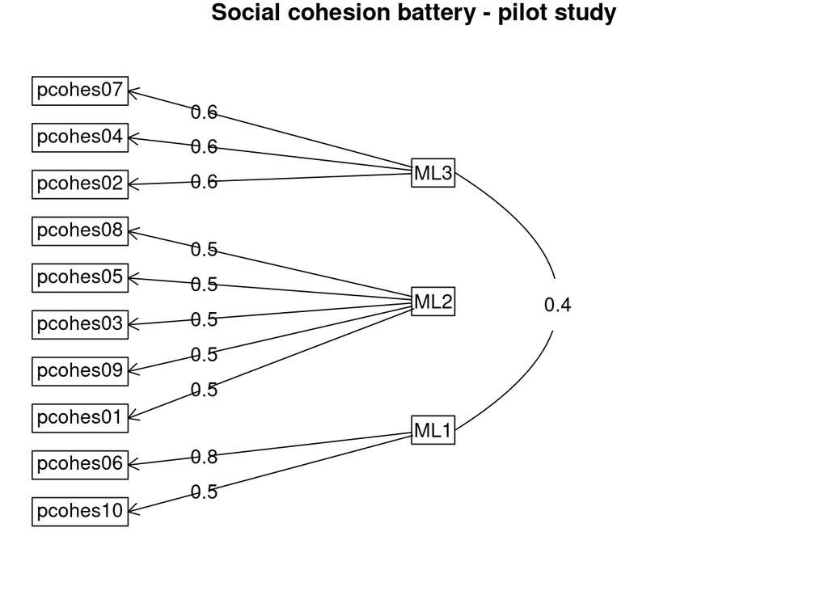

```r
fa.diagram(M1_pilot, main="Social cohesion battery - pilot study")
```

### 3.3.2 Tables

```r
source("https://raw.githubusercontent.com/franciscowilhelm/r-collection/master/fa_table.R")

tables <- fa_table(M1_pilot)
tables$ind_table
```

Factor analysis results

|  | Factor_1 | Factor_2 | Factor_3 | Communality | Uniqueness | Complexity |
| --- | --- | --- | --- | --- | --- | --- |
| pcohes07 | 0.618 | 0.110 | 0.050 | 0.43 | 0.57 | 1.08 |
| pcohes04 | 0.601 | -0.139 | 0.075 | 0.40 | 0.60 | 1.14 |
| pcohes02 | 0.586 | 0.053 | 0.142 | 0.43 | 0.57 | 1.13 |
| pcohes08 | -0.204 | 0.530 | 0.064 | 0.30 | 0.70 | 1.32 |
| pcohes05 | 0.262 | 0.498 | -0.115 | 0.32 | 0.68 | 1.64 |
| pcohes03 | -0.200 | 0.480 | 0.128 | 0.26 | 0.74 | 1.49 |
| pcohes09 | 0.212 | 0.467 | -0.093 | 0.27 | 0.73 | 1.48 |
| pcohes01 | 0.157 | 0.450 | -0.003 | 0.24 | 0.76 | 1.24 |
| pcohes06 | 0.090 | -0.056 | 0.797 | 0.69 | 0.31 | 1.04 |
| pcohes10 | -0.056 | 0.267 | 0.500 | 0.32 | 0.68 | 1.56 |

```r
tables$f_table
```

Eigenvalues, Variance Explained, and Factor Correlations for Rotated Factor Solution

| Property | Factor_1 | Factor_2 | Factor_3 |
| --- | --- | --- | --- |
| SS loadings | 1.367 | 1.303 | 1.005 |
| Proportion Var | 0.137 | 0.130 | 0.100 |
| Cumulative Var | 0.137 | 0.267 | 0.367 |
| Proportion Explained | 0.372 | 0.355 | 0.273 |
| Cumulative Proportion | 0.372 | 0.727 | 1.000 |
| Factor_1 | 1.000 | 0.084 | 0.370 |
| Factor_2 | 0.084 | 1.000 | 0.083 |
| Factor_3 | 0.370 | 0.083 | 1.000 |

### 3.3.3 Alternative table (sjPlot - with value labels)

```r
data_cohes_pilot %>% select(pcohes02,pcohes04,pcohes07, pcohes01,pcohes03,pcohes05,pcohes08,pcohes09, pcohes06,pcohes10) %>%
sjPlot::tab_fa(., method = "ml", nmbr.fctr = 3, rotation = "varimax", alternate.rows = FALSE)
```

Factor Analysis

|  | Factor 1 | Factor 2 | Factor 3 |
| --- | --- | --- | --- |
| Develop freely | 0.62 | 0.11 | 0.19 |
| Different cultures | 0.62 | -0.07 | 0.10 |
| Compromises worked out | 0.62 | 0.17 | 0.11 |
| Place in society | 0.14 | 0.46 | 0.07 |
| Share values | -0.18 | 0.45 | 0.17 |
| Law & order | 0.21 | 0.53 | -0.02 |
| Clear leadership | -0.20 | 0.50 | 0.12 |
| Tight links | 0.17 | 0.49 | -0.01 |
| Live as wanted | 0.33 | -0.07 | 0.76 |
| Live freely | 0.09 | 0.24 | 0.51 |
| Cronbach’s α | 0.66 | 0.58 | 0.57 |

Conclusion: there is a three factor structure in the pilot data, now we will compare this underlying structure with the panel data.

# 4 Panel study - first wave

## 4.1 Data

```r
load(file = "01-input/data/proc/data_cohes_panel.Rdata" )
names(data_cohes_panel)
```

```
##  [1] "pid"      "pcohes01" "pcohes02" "pcohes03" "pcohes04" "pcohes05"
##  [7] "pcohes06" "pcohes07" "pcohes08" "pcohes09" "pcohes10" "pcohes11"
## [13] "pcohes12" "careless"
```

```r
# stargazer(as.data.frame(data_cohes), type="text")
```

## 4.2 Bivariate

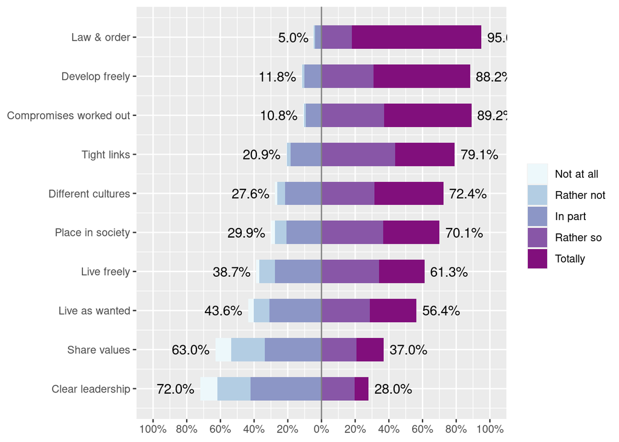

```r
data_cohes_panel %>% select(pcohes05,pcohes02,pcohes07, pcohes09, pcohes04,pcohes01,pcohes10,pcohes06,pcohes03,pcohes08) %>% plot_likert(.,
  values = "sum.outside",
  show.prc.sign = TRUE,
  reverse.scale = TRUE,
  expand.grid = T,
  catcount = 5,
  show.n = FALSE,
  geom.colors = "BuPu")
```

```r
M_panel <-
data_cohes_panel %>% select(pcohes02,pcohes04,pcohes07,pcohes11,pcohes12, pcohes01,pcohes03,pcohes05,pcohes08,pcohes09, pcohes06,pcohes10) %>%
sjPlot::tab_fa(., method = "ml", nmbr.fctr = 3, rotation = "varimax", alternate.rows = FALSE)
```

## 4.3 Factor analysis

### 4.3.1 Estimate with fa (psych library)

```r
efa_panel <- data_cohes_panel %>% select(pcohes01:pcohes12)

M1_panel <- fa (efa_panel, nfactors=3, rotate="oblimin", fm="ml")
M1_panel
```

```
## Factor Analysis using method =  ml
## Call: fa(r = efa_panel, nfactors = 3, rotate = "oblimin", fm = "ml")
## Standardized loadings (pattern matrix) based upon correlation matrix
##            ML1   ML2   ML3   h2   u2 com
## pcohes01  0.09  0.51 -0.01 0.28 0.72 1.1
## pcohes02  0.37  0.08  0.24 0.27 0.73 1.8
## pcohes03 -0.08  0.57  0.07 0.33 0.67 1.1
## pcohes04  0.55 -0.14  0.05 0.32 0.68 1.2
## pcohes05  0.24  0.43 -0.08 0.26 0.74 1.6
## pcohes06  0.10 -0.08  0.66 0.48 0.52 1.1
## pcohes07  0.57  0.02  0.08 0.37 0.63 1.0
## pcohes08 -0.13  0.49  0.00 0.24 0.76 1.1
## pcohes09  0.12  0.41  0.00 0.19 0.81 1.2
## pcohes10 -0.09  0.23  0.51 0.31 0.69 1.5
## pcohes11  0.41  0.06  0.16 0.25 0.75 1.3
## pcohes12  0.49  0.14 -0.16 0.25 0.75 1.4
##
##                        ML1  ML2  ML3
## SS loadings           1.36 1.31 0.87
## Proportion Var        0.11 0.11 0.07
## Cumulative Var        0.11 0.22 0.29
## Proportion Explained  0.38 0.37 0.25
## Cumulative Proportion 0.38 0.75 1.00
##
##  With factor correlations of
##      ML1  ML2  ML3
## ML1 1.00 0.12 0.31
## ML2 0.12 1.00 0.10
## ML3 0.31 0.10 1.00
##
## Mean item complexity =  1.3
## Test of the hypothesis that 3 factors are sufficient.
##
## The degrees of freedom for the null model are  66  and the objective function was  1.42 with Chi Square of  18468.3
## The degrees of freedom for the model are 33  and the objective function was  0.07
##
## The root mean square of the residuals (RMSR) is  0.02
## The df corrected root mean square of the residuals is  0.03
##
## The harmonic number of observations is  12731 with the empirical chi square  896.54  with prob <  0.000000000000000000000000000000000000000000000000000000000000000000000000000000000000000000000000000000000000000000000000000000000000000000000000000000000000000000000052
## The total number of observations was  13055  with Likelihood Chi Square =  874.46  with prob <  0.0000000000000000000000000000000000000000000000000000000000000000000000000000000000000000000000000000000000000000000000000000000000000000000000000000000000000000022
##
## Tucker Lewis Index of factoring reliability =  0.909
## RMSEA index =  0.044  and the 90 % confidence intervals are  0.042 0.047
## BIC =  561.72
## Fit based upon off diagonal values = 0.98
## Measures of factor score adequacy
##                                                    ML1  ML2  ML3
## Correlation of (regression) scores with factors   0.81 0.80 0.77
## Multiple R square of scores with factors          0.66 0.64 0.60
## Minimum correlation of possible factor scores     0.33 0.28 0.20
```

[figure not shown]

```r
fa.diagram(M1_panel, main="Social cohesion battery - pilot study")
```

### 4.3.2 Tables

```r
source("https://raw.githubusercontent.com/franciscowilhelm/r-collection/master/fa_table.R")

tables_panel <- fa_table(M1_panel)
tables_panel$ind_table
```

Factor analysis results

|  | Factor_1 | Factor_2 | Factor_3 | Communality | Uniqueness | Complexity |
| --- | --- | --- | --- | --- | --- | --- |
| pcohes07 | 0.570 | 0.025 | 0.084 | 0.37 | 0.63 | 1.05 |
| pcohes04 | 0.547 | -0.143 | 0.053 | 0.32 | 0.68 | 1.16 |
| pcohes12 | 0.495 | 0.136 | -0.163 | 0.25 | 0.75 | 1.38 |
| pcohes11 | 0.412 | 0.056 | 0.162 | 0.25 | 0.75 | 1.34 |
| pcohes02 | 0.372 | 0.083 | 0.239 | 0.27 | 0.73 | 1.82 |
| pcohes03 | -0.076 | 0.567 | 0.068 | 0.33 | 0.67 | 1.06 |
| pcohes01 | 0.095 | 0.510 | -0.009 | 0.28 | 0.72 | 1.07 |
| pcohes08 | -0.128 | 0.488 | -0.002 | 0.24 | 0.76 | 1.14 |
| pcohes05 | 0.237 | 0.434 | -0.083 | 0.26 | 0.74 | 1.64 |
| pcohes09 | 0.123 | 0.408 | -0.005 | 0.19 | 0.81 | 1.18 |
| pcohes06 | 0.102 | -0.076 | 0.660 | 0.48 | 0.52 | 1.07 |
| pcohes10 | -0.088 | 0.233 | 0.505 | 0.31 | 0.69 | 1.48 |

```r
tables_panel$f_table
```

Eigenvalues, Variance Explained, and Factor Correlations for Rotated Factor Solution

| Property | Factor_1 | Factor_2 | Factor_3 |
| --- | --- | --- | --- |
| SS loadings | 1.358 | 1.305 | 0.875 |
| Proportion Var | 0.113 | 0.109 | 0.073 |
| Cumulative Var | 0.113 | 0.222 | 0.295 |
| Proportion Explained | 0.384 | 0.369 | 0.247 |
| Cumulative Proportion | 0.384 | 0.753 | 1.000 |
| Factor_1 | 1.000 | 0.117 | 0.310 |
| Factor_2 | 0.117 | 1.000 | 0.097 |
| Factor_3 | 0.310 | 0.097 | 1.000 |

### 4.3.3 Alternative (sjPlot)

```r
data_cohes_panel %>% select(pcohes02,pcohes04,pcohes07,pcohes11,pcohes12, pcohes01,pcohes03,pcohes05,pcohes08,pcohes09, pcohes06,pcohes10) %>%
sjPlot::tab_fa(., method = "ml", nmbr.fctr = 3, rotation = "varimax", alternate.rows = FALSE)
```

Factor Analysis

|  | Factor 1 | Factor 2 | Factor 3 |
| --- | --- | --- | --- |
| Develop freely | 0.43 | 0.11 | 0.27 |
| Different cultures | 0.55 | -0.10 | 0.08 |
| Compromises worked out | 0.59 | 0.06 | 0.13 |
| Political influence | 0.45 | 0.08 | 0.20 |
| Self restrict | 0.46 | 0.17 | -0.11 |
| Place in society | 0.11 | 0.51 | 0.05 |
| Share values | -0.04 | 0.56 | 0.11 |
| Law & order | 0.23 | 0.45 | -0.02 |
| Clear leadership | -0.11 | 0.48 | 0.03 |
| Tight links | 0.14 | 0.42 | 0.04 |
| Live as wanted | 0.25 | -0.07 | 0.64 |
| Live freely | 0.04 | 0.22 | 0.51 |
| Cronbach’s α | 0.62 | 0.59 | 0.48 |

# 5 General conclusion

- The factor structrue is consistent between the pilot and the panel study.
- The panel additional items (2) are part of the first dimension
- Three main factors are extracted, which could be named as “universal values”, “traditional” and “free-riders”.
- Although the structure is stable between studies, there were some problems when trying to proceed with confirmatory factor analysis as the factor loadings are rather weak and the explained variance is low (see proc_analysys_cfa.Rmd).

Next:

- get factor scores and proceed to regression models.
- graphical representation of the prevalece of the three dimensions at territorial level (map).